# A-18033

18033

2019.01.10

## H1 A-18033-2018-09-14

## Example 1 : Random

100 random number from normal ,mean = 0, sigma = 1

```r
set.seed(1)
x <- rnorm(100,0,1)
x
```

```
##   [1] -0.626453811  0.183643324 -0.835628612  1.595280802  0.329507772
##   [6] -0.820468384  0.487429052  0.738324705  0.575781352 -0.305388387
##  [11]  1.511781168  0.389843236 -0.621240581 -2.214699887  1.124930918
##  [16] -0.044933609 -0.016190263  0.943836211  0.821221195  0.593901321
##  [21]  0.918977372  0.782136301  0.074564983 -1.989351696  0.619825748
##  [26] -0.056128740 -0.155795507 -1.470752384 -0.478150055  0.417941560
##  [31]  1.358679552 -0.102787727  0.387671612 -0.053805041 -1.377059557
##  [36] -0.414994563 -0.394289954 -0.059313397  1.100025372  0.763175748
##  [41] -0.164523596 -0.253361680  0.696963375  0.556663199 -0.688755695
##  [46] -0.707495157  0.364581962  0.768532925 -0.112346212  0.881107726
##  [51]  0.398105880 -0.612026393  0.341119691 -1.129363096  1.433023702
##  [56]  1.980399899 -0.367221476 -1.044134626  0.569719627 -0.135054604
##  [61]  2.401617761 -0.039240003  0.689739362  0.028002159 -0.743273209
##  [66]  0.188792300 -1.804958629  1.465554862  0.153253338  2.172611670
##  [71]  0.475509529 -0.709946431  0.610726353 -0.934097632 -1.253633400
##  [76]  0.291446236 -0.443291873  0.001105352  0.074341324 -0.589520946
##  [81] -0.568668733 -0.135178615  1.178086997 -1.523566800  0.593946188
##  [86]  0.332950371  1.063099837 -0.304183924  0.370018810  0.267098791
##  [91] -0.542520031  1.207867806  1.160402616  0.700213650  1.586833455
##  [96]  0.558486426 -1.276592208 -0.573265414 -1.224612615 -0.473400636
```

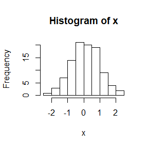

```r
hist(x)
```

## Q1

For exercise 9.6, use the Gelman-Rubin method to monitor convergence of the chain, and run the chain until the chain has converged approximately to the target distribution according to $\hat R < 1.2$.

## A1

```r
#9.6
#It is obvious that theta belongs to [0,1]
#i chooose the beta(1+a,2-a) as the proposal distrubution
#
#(125,18,20,34)
#
CMD <- function(theta){
  #return the probabilities vector of the corresponding multinomial distribution
  if(theta >1) return(c(0,0,0,0))
  if(theta <0) return(c(0,0,0,0))
  return(c(0.5+theta/4,(1-theta)/4,(1-theta)/4,theta/4))
}

LMCMD <- function(r,data){
  p <- CMD(r)
  return(p[1]^data[1]*p[2]^data[2]*p[3]^data[3]*p[4]^data[4])
}

MCMC2 <- function(N,data,startx=0.5){
  mchain <- numeric(N)
  mchain[1] = startx
  k=0
  for(i in 1:(N-1)){
    r <- rbeta(1,1+mchain[i],2-mchain[i])
    a = LMCMD(r,data) * dbeta(mchain[i],1+r,2-r)/ LMCMD(mchain[i],data)/  dbeta(r,1+mchain[i],2-mchain[i])
    nr <-runif(1)
    if(nr<a) mchain[i+1]=r else mchain[i+1]=mchain[i]
  }
  return(mchain)
}


#cov

Gelman.Rubin <- function(psi) {
  # psi[i,j] is the statistic psi(X[i,1:j])
  # for chain in i-th row of X
  psi <- as.matrix(psi)
  n <- ncol(psi)
  k <- nrow(psi)
  psi.means <- rowMeans(psi) #row means
  B <- n * var(psi.means) #between variance est.
  psi.w <- apply(psi, 1, "var") #within variances
  W <- mean(psi.w) #within est.
  v.hat <- W*(n-1)/n + (B/n) #upper variance est.
  r.hat <- v.hat / W #G-R statistic
  return(r.hat)
}

set.seed(123)
k=3
N=5000
data <- c(125,18,20,34)
startx <- c(0.1,0.5,0.9)
startn <-1000
a <- matrix(0,k,N)
for (j in 1:k){
  mchain2 <- MCMC2(N,data,startx[j])
  a[j,] <- mchain2
}

Gelman.Rubin(a)
```

```
## [1] 1.003609
```

```r
n=5
psi <- t(apply(a, 1, cumsum))
for (i in 1:nrow(psi)) psi[i,] <- psi[i,] / (1:ncol(psi))
print(Gelman.Rubin(psi))
```

```
## [1] 1.099351
```

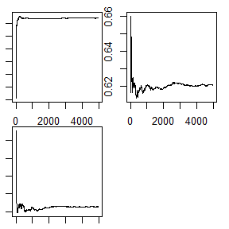

```r
#plot psi for the three chains
par(mfrow=c(2,2),mar=c(1,1,1,1))
for (i in 1:k) plot(psi[i, (n+1):N], type="l", xlab=i, ylab=bquote(psi))
par(mfrow=c(1,1)) #restore default
```

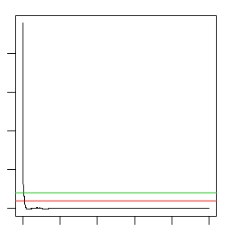

```r
#plot the sequence of R-hat statistics rhat <- rep(0, n) for (j in (b+1):n) rhat[j] <- Gelman.Rubin(psi[,1:j]) plot(rhat[(b+1):n], type="l", xlab="", ylab="R") abline(h=1.1, lty=2)

b <- numeric(N-n+1)
for(i in n:N)
  b[i-n+1]=Gelman.Rubin(a[,1:i])
plot(n:N,b,type="l",ylab="R")
abline(h=1.2,col=3)
abline(h=1.1,col=2)
```

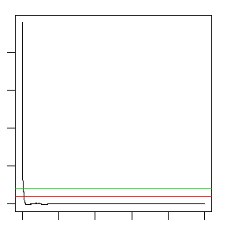

```r
#top 50 5-50
plot(n:N/100,b,type="l",ylab="R")
abline(h=1.2,col=3)
abline(h=1.1,col=2)
```

```r
# chain has approximately converged to the target distribution within approximately 5000 iterations
#
# chain has approximately converged to the target distribution within approximately 5000 iterations
```

# Q2

Find the intersection points A(k) in (0 ,$\sqrt k$) of the curves

# A2

for the upper sqrt(k) is unavailable and the lower 0 is also a ooot ,I first add a small deviation : 1e-5. After the first part , I change the upper for the right answer what I want

```r
Sk_1 <- function(a,k){
  q <- sqrt(a^2*(k-1)/(k-a^2))
  return (1-pt(q,df=k-1))
}
Sk <- function(a,k){
  q <- sqrt(a^2*k/(k+1-a^2))
  return (1-pt(q,df=k))
}
difSK <- function(x,k) {
  Sk_1(x,k)-Sk(x,k)
}
kset <- c(4:25,100,500,1000)
out <- 1:length(kset)
for (i in 1:length(kset)){
  out[i] <- uniroot( difSK
                     , lower = 0+1e-5, upper = sqrt(kset[i])-1e-5,k=kset[i]) $root
}
out
```

```
##  [1]  1.492103  1.533549  1.562768  1.584421  1.601182  1.614523  1.625387
##  [8]  1.634409  1.642025  1.648540  1.654177  1.659098  1.663451  1.667288
## [15]  1.670736  1.673841  1.676588  1.679139  1.681461  4.795822  4.898969
## [22]  4.999990  9.999990 22.360670 31.622767
```

```r
###########
#not all right
###########

kset[ abs(out-sqrt(kset)) < sqrt(kset)*0.01]
```

```
## [1]   23   24   25  100  500 1000
```

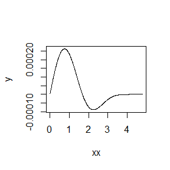

```r
#It is shown that when k large than 22 ,the root is a wrong ,so we musst change the
n <- 1:length(kset)
Kwrongnum <- n[abs(out-sqrt(kset)) < sqrt(kset)*0.01]

#based on the curve and the increasing of the answer,I change the upper
#Example : k=23
k=23
xx <- seq(0.01,sqrt(k)-1e-5,length=1000)
y <- difSK(xx,k)
plot(xx,y,type="l")
```

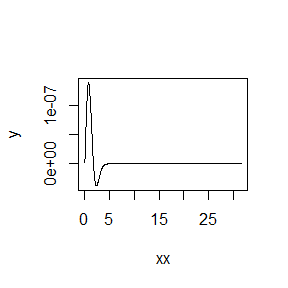

```r
#Example : k=1000
k=1000
xx <- seq(0.01,sqrt(k)-1e-5,length=1000)
y <- difSK(xx,k)
plot(xx,y,type="l")
```

```r
#change upper to 3

for (i in Kwrongnum){
  out[i] <- uniroot( difSK
                     , lower = 0+1e-5, upper =3,k=kset[i]) $root
}
names(out) <- kset

out
```

```
##        4        5        6        7        8        9       10       11
## 1.492103 1.533549 1.562768 1.584421 1.601182 1.614523 1.625387 1.634409
##       12       13       14       15       16       17       18       19
## 1.642025 1.648540 1.654177 1.659098 1.663451 1.667288 1.670736 1.673841
##       20       21       22       23       24       25      100      500
## 1.676588 1.679139 1.681461 1.683594 1.685546 1.687347 1.720601 1.729747
##     1000
## 1.730911
```

## Example 2 : data

```r
iris
```

```
##     Sepal.Length Sepal.Width Petal.Length Petal.Width    Species
## 1            5.1         3.5          1.4         0.2     setosa
## 2            4.9         3.0          1.4         0.2     setosa
## 3            4.7         3.2          1.3         0.2     setosa
## 4            4.6         3.1          1.5         0.2     setosa
## 5            5.0         3.6          1.4         0.2     setosa
## 6            5.4         3.9          1.7         0.4     setosa
## 7            4.6         3.4          1.4         0.3     setosa
## 8            5.0         3.4          1.5         0.2     setosa
## 9            4.4         2.9          1.4         0.2     setosa
## 10           4.9         3.1          1.5         0.1     setosa
## 11           5.4         3.7          1.5         0.2     setosa
## 12           4.8         3.4          1.6         0.2     setosa
## 13           4.8         3.0          1.4         0.1     setosa
## 14           4.3         3.0          1.1         0.1     setosa
```

[output cut: 136 more lines]

## Example 3 : Plot

QQ-plot and residual error of liner model of iris

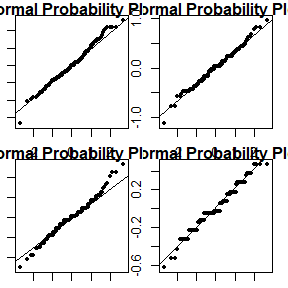

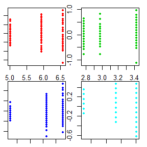

## H2 A-18033-2018-09-21

## Q1

3.5 A discrete random variable X has probability mass function

| X | 0 | 1 | 2 | 3 | 4 |
| --- | --- | --- | --- | --- | --- |
| p | 0.1 | 0.2 | 0.2 | 0.2 | 0.3 |

Use the inverse transform method to generate a random sample of size 1000 from the distribution of X. Construct a relative frequency table and compare the empirical with the theoretical probabilities. Repeat using the R sample function.

## A1

Table 1???a relative frequency table using the inverse transform method to generate

|  | 0 | 1 | 2 | 3 | 4 |
| --- | --- | --- | --- | --- | --- |
| empirical | 0.099 | 0.197 | 0.211 | 0.198 | 0.295 |
| theoretical | 0.100 | 0.200 | 0.200 | 0.200 | 0.300 |

Table 2???a relative frequency table using Sample

|  | 0 | 1 | 2 | 3 | 4 |
| --- | --- | --- | --- | --- | --- |
| empirical | 0.085 | 0.212 | 0.205 | 0.2 | 0.298 |
| theoretical | 0.100 | 0.200 | 0.200 | 0.2 | 0.300 |

Rcode and the note ???

```r
X <- c(0:4)
p <- c(0.1,0.2,0.2,0.2,0.3)
csp <-  cumsum(p)
#the inverse transform method
ITMSample <- function(x,csp,N){
  #x???sample csp???Cumulative Distribution Function  N???Number of Sample
  csp<-c(csp,1)
  y<-1:N
  #note theresult
  r<-runif(N)
  #gemerate random numbers
  for(i in 1:N){
    k = r[i]
    j=1
    while(csp[j]<k) j=j+1
    y[i]=x[j]
  }
  return(y)
}
set.seed(123)
N<-1000
rus1<-ITMSample(X,csp,N)
tableRE1 <- rbind(table(rus1),p)
tableRE1[1,]<-tableRE1[1,]/N
rownames(tableRE1)<- c('empirical','theoretical')
#knitr::kable(tableRE1, caption="Table 1???a relative frequency table using the inverse transform method to generate ")
#make the table

#sample
rus2<-sample(X,N,replace = TRUE,prob=p)
tableRE2 <- rbind(table(rus2),p)
tableRE2[1,]<-tableRE2[1,]/N
rownames(tableRE2)<- c('empirical','theoretical')
#knitr::kable(tableRE2, caption="Table 2???a relative frequency table using Sample ")
#make the table
```

## Q2

3.7 Write a function to generate a random sample of size n from the Beta(a,b) distribution by the acceptance-rejection method. Generate a random sample of size 1000 from the Beta(3,2) distribution. Graph the histogram of the sample with the theoretical Beta(3,2) density superimposed.

## A2

For the range of beta distribution is (0,1) and the maximum of density function of beta(3,2) below than 1.8, I choose the uniform distribution and c =1.8

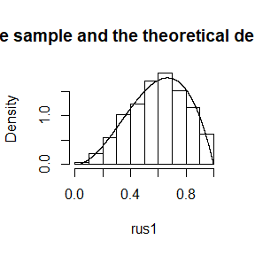

Rcode and the note ???

```r
#find the maximum of density function
x<-seq(0,1,0.0001)
N<-length(x)
y<-1:N
for(i in 1:N){
  y[i]<-dbeta(x[i],3,2)
}
#max(y)
#function acceptance-rejection method
ARMsample_beta <- function(beta1,beta2,maxd,N){
  #beta1,beta2 the non-negative parameters of the Beta distribution.
  #maxd the c of acceptance-rejection method
  #N number before rejection
  r1<-runif(N)
  #??????????????????
  y <- NULL
  for(i in 1:N){
    if(dbeta(r1[i],beta1,beta2)> maxd*runif(1) ) y<-c(y,r1[i])
    #????????????
  }
  return(y)
}
set.seed(1234)
rus<-ARMsample_beta(3,2,1.8,2000)
#length(rus)
#???????????????37%
rus1<-rus[1:1000]
#hist(rus1,main=" histogram of the sample and the theoretical density superimposed",freq=FALSE)
#lines(x,y)
```

## A3

first I use the rgamma to aenerate the random number from Gamma(r,??),then use the rexpto aenerate the random number

the function called rExp_Gamma

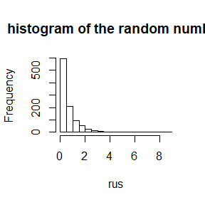

```r
rExp_Gamma <- function(r,beta,N){
  #N number
  y<-1:N
  for (i in 1:N){
    x<- rgamma(1,r,beta)
    y[i]<-rexp(1,x)
  }
  return(y)
}
set.seed(12)
rus<-rExp_Gamma(4,2,1000)
hist(rus,breaks=seq(0,max(rus)+0.5,0.5),main="histogram of the random number")
```

## H3 R-18033-2018-09-28

## Q1

5.4 Write a function to compute a Monte Carlo estimate of the Beta(3, 3) cdf, and use the function to estimate F(x) forx =0 .1,0.2,…,0.9. Compare the estimates with the values returned by the pbeta function in R.

## A1

I use betacdfMC function to generate random numbers and estimate the cdf There are estimated values by generating 10000,100000,1000000 random numbers and theoretical value from pbeta function

```r
betacdfMC <- function(x,beta1,beta2,N=10000) {
  #x F(x),x can be a number or a vector
  ##beta1,beta2 the non-negative parameters of the Beta distribution.
  #N numbers of random number
  y<-rbeta(N,3,3)
  X<-matrix(x,length(x),N)
  Y<-matrix(y,length(x),N,byrow=T)
  #
  return(rowSums(Y<=X)/N)
}
set.seed(123)
A1_1<-betacdfMC(seq(0.1,0.9,0.1),3,3)
#A1_1
#100000
A1_2<-betacdfMC(seq(0.1,0.9,0.1),3,3,100000)
#A1_2
#1000000
A1_3<-betacdfMC(seq(0.1,0.9,0.1),3,3,1000000)
#A1_3
#theoretical value
A1_t<-pbeta(seq(0.1,0.9,0.1),3,3)
#A1_t

A1 <- rbind(A1_1,A1_2,A1_3,A1_t)
colnames(A1)<-c(seq(0.1,0.9,0.1))
rownames(A1)<-c(1e+04,1e+05,1e+06,'theoretical')
A1
```

```
##                  0.1      0.2      0.3      0.4      0.5     0.6      0.7
## 10000       0.009700 0.061000 0.164400 0.315600 0.504300 0.68220 0.835200
## 1e+05       0.008520 0.057940 0.162470 0.317020 0.498770 0.68076 0.836960
## 1e+06       0.008595 0.057645 0.163426 0.318259 0.500518 0.68307 0.837106
## theoretical 0.008560 0.057920 0.163080 0.317440 0.500000 0.68256 0.836920
##                  0.8      0.9
## 10000       0.944600 0.992000
## 1e+05       0.941460 0.991660
## 1e+06       0.942014 0.991463
## theoretical 0.942080 0.991440
```

## Q2

5.9 The Rayleigh density [156, (18.76)] is $f(x)= \frac{x}{??^2}e^{-\frac{x^2}{2??^2}}$,x ???0,??>0. Implement a function to generate samples from a Rayleigh(??) distribution, using antithetic variables. What is the percent reduction in variance of $\frac{X+X'}{2}$ compared with $\frac{X1+X2}{2}$ for independent X1, X2?

##A2 I find the inverse cdf to connect the antithetic variables U from uniform(0,1) to X

cdf: $F(x)=1-e^{-\frac{x^2}{2??^2}}$ inverse cdf:$F^{-1}(u)=\sqrt{-2??^2ln(1-u)}$

the variance of $\frac{X+X'}{2}$ is 1.258606e-06

the variance of $\frac{X1+X2}{2}$ is 1.892159e-05

the variance of using antithetic variables is 0.0665169 of independent’s

```r
invcdfRay <- function(u,e) return(sqrt(-2*e*e*log(1-u)))
#e :??
simpleicRa <- function(Sigma,N=1000){
#sigma: the parameter of Rayleigh(??) distribution
#N numbers of random
#The function creates N random numbers And N antithetic random number
#the first N number is indenpendent ,the last N is antithetic of the top N
u<-runif(N)
y<-rep(0,2*N)
for(i in 1:N){
y[i]<-invcdfRay(u[i],Sigma)
y[i+N]<-invcdfRay(1-u[i],Sigma)
}
return(y)
}
#I create 1000(N) random numbers 1000(n) times
set.seed(123)
n=100
N=10000
sigma=1
x=xnew<-matrix(0,n,2*N)
for(i in 1:n){
x[i,]<-simpleicRa(sigma,N)
}
for(i in 1:n){
xnew[i,]<-simpleicRa(sigma,N)
}
n=n-n%%2
#xin and x1: (X1+X2)/2 and y1 : n estimated value
xin<-matrix(0,n,N)
for(i in 1:n){
xin[i,] <- (x[i,1:N]+xnew[i,1:N])/2
}
y1<-rowMeans(xin)

#x2 and xan X+X' and y2 : n estimated value
xanti<-matrix(0,n,N)
for(i in 1:n){
  xanti[i,] <- (x[i,1:N]+x[i,N+1:N])/2
}
y2<-rowMeans(xanti)
var(y1)
```

```
## [1] 1.892159e-05
```

```r
var(y2)
```

```
## [1] 1.258606e-06
```

```r
var(y2)/var(y1)
```

```
## [1] 0.0665169
```

```r
#var(y2) < var (y1)
```

## Q3

5.13 Find two importance functions f1 and f2 that are supported on (1,???) and are ???close??? to $g(x)= \frac{x^2} {\sqrt{2??}} e^{-\frac{x^2}{2}}$ , x > 1. Which of your two importance functions should produce the smaller variance in estimating $\int_{1}^{\infty} \frac{x^2}{\sqrt{2??}}e^{-\frac{x^2}{2}} dx$ by importance sampling? Explain.

## A3

I choose two function:

f1 : $f_{1}(x)= \frac{x} {\sqrt{e} }e^{-\frac{x^2}{2}} I(X\ge1)$

f2 : $f_{2}(x)= \frac{1}{2}e^{-\frac{x-1}{2}} I(X\ge1)$

both functions are normalizated

f1 should produce the smaller variance in estimating $\int_{1}^{\infty} \frac{x^2}{\sqrt{2??}}e^{-\frac{x^2}{2}} dx$ by importance sampling,becasuse that ( in the main part of g(x) ) (maybe x<=4 or x<=6),f1 is more closer to g(x) than f2 by comparing $\frac{f_2(x)}{g(x)}$ and$\frac{f_1(x)}{g(x)}$

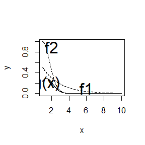

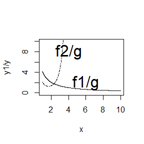

R code :

```r
funcg <- function(x) if(x>=1) x*x*exp(-x*x/2)/sqrt(2*pi) else 0
funcg_vec <-function(X) {
  n<-length(X)
  y<-1:n
  for(i in 1:n)
    y[i]<-funcg(X[i])
  return(y)
}

funcf1 <- function(x) if(x>=1) x*exp(-x*x/2)*exp(1/2) else 0
funcf1_vec <-function(X) {
  n<-length(X)
  y<-1:n
  for(i in 1:n)
    y[i]<-funcf1(X[i])
  return(y)
}
funcf2 <- function(x) if(x>=1) exp(-x/2)/2*exp(1/2) else 0
funcf2_vec <-function(X) {
  n<-length(X)
  y<-1:n
  for(i in 1:n)
    y[i]<-funcf2(X[i])
  return(y)
}
#x<-seq(1,10,0.001)
#y<-funcg_vec(x)
#plot(x,y,ylim=c(0,1),type='l')
#y2<-funcf2_vec(x)
#lines(x,y2,lty=2)
#text(2,0.9,'f2',cex=2)
#y1<-funcf1_vec(x)
#lines(x,y1,lty=10)
#text(6,0.1,'f1',cex=2)
#text(1.5,0.2,'g(x)',cex=2)
#plot(x,y1/y,type='l',ylim=c(0,10))
#lines(x,y2/y,lty=10)
#text(6,2,'f1/g',cex=2)
#text(4,8,'f2/g',cex=2)
```

## Q4

5.14 Obtain a Monte Carlo estimate of

$\int_{1}^{\infty} \frac{x^2}{\sqrt{2??}}e^{-\frac{x^2}{2}} dx$

by importance sampling.

## A4

I use the code from Q3 and generate 10000 random numbers by using inverse cdf.

cdf f1: $F_{1}(x)=1-e^{\frac{1-x^2}{2}}$

inverse cdf f1 : $F^{-1}_{1}(u)=\sqrt{1-2ln(1-u)}$

estimated value from f1 :0.3990829

estimated value from f1 using antithetic variables:0.4002061

cdf f2???$F_{2}(x)=1-e^{\frac{1-x}{2}}$

inverse cdf f2:$F^{-1}_{2}(u)=1-2ln(1-u)$

estimated value from f2: 0.4044936

Rcode :

```r
set.seed(123)
N=10000
u1<-runif(N)
cdff1 <- function(x) 1-exp(-x^2/2+1/2)
Invcdff1 <- function(u) sqrt(1-2*log(1-u))
Invcdff1_vec <- function(X) {
  n<-length(X)
  y<-1:n
  for(i in 1:n)
    y[i]<-Invcdff1(X[i])
  return(y)
}
x1 <- Invcdff1_vec(u1)
y1<-sum(funcg_vec(x1)/funcf1_vec(x1))/N
y1
```

```
## [1] 0.3990829
```

```r
x1_an <- c(Invcdff1_vec(u1),Invcdff1_vec(1-u1))
y1_an <- sum(funcg_vec(x1_an)/funcf1_vec(x1_an))/N/2
y1_an
```

```
## [1] 0.4002061
```

```r
u2<-runif(N)
cdff2 <- function(x) 1-exp(-x/2+1/2)
Invcdff2 <- function(u) (1-2*log(1-u))
Invcdff2_vec <- function(X) {
  n<-length(X)
  y<-1:n
  for(i in 1:n)
    y[i]<-Invcdff2(X[i])
  return(y)
}
x2 <- Invcdff2_vec(u2)
y2<-sum(funcg_vec(x2)/funcf2_vec(x2))/N
y2
```

```
## [1] 0.4044936
```

```r
x2_an <- c(Invcdff2_vec(u2),Invcdff2_vec(1-u2))
y2_an <- sum(funcg_vec(x2_an)/funcf2_vec(x2_an))/N/2
y2_an
```

```
## [1] 0.4009006
```

## H4 A-18033-2018-10-12

## Q1

6.9 Let $X$ be a non-negative random variable with $\mu=E[X]<\infty$. For a random sample $x_1,...,x_n$ from the distribution of $X$, the Gini ratio is de???ned by

$G=\frac{1}{2n^2\mu}\sum_{i=1}^{n}\sum_{j=1}^{n}|x_i-x_j|$

The Gini ratio is applied in economics to measure inequality in income distribution (see e.g. [163]). Note that G can be written in terms of the order statistics $x_{(i)}$ as

$G=\frac{1}{n^2\mu}\sum_{i=1}^{n}(2i-n-1)x_{(i)}$

If the mean is unknown,let $\hat{G}$ be the statistic $G$ with ?? replacedby $\bar{x}$. Estimate by simulation the mean, median and deciles of $\hat{G}$ if $X$ is standard lognormal. Repeat the procedure for the uniform distribution and Bernoulli(0.1). Also construct density histograms of the replicates in each case.

## A1

function GiniratioV is used for calculating the G

I generate 10000 random numbers 1000 times to calculate $\hat{G}$ 1000 times

### $X$ is standard lognormal:

the mean:

`## [1] 0.5205809` the median

```
## [1] 0.5207894
```

the deciles

```
##       10%       20%       30%       40%       50%       60%       70%
## 0.5150181 0.5170814 0.5184025 0.5194999 0.5207894 0.5219313 0.5230189
##       80%       90%
## 0.5241111 0.5258198
```

the density histograms

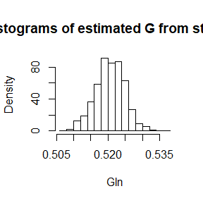

### $X$ is uniform:

the mean:

`## [1] 0.3333285` the median

```
## [1] 0.3333709
```

the deciles

```
##       10%       20%       30%       40%       50%       60%       70%
## 0.3301683 0.3312522 0.3321174 0.3327340 0.3333709 0.3340040 0.3346054
##       80%       90%
## 0.3353948 0.3363167
```

the density histograms

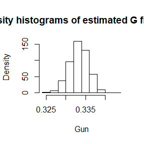

### $X$ is Bernoulli(0.1):

the mean:

`## [1] 0.9001011` the median

```
## [1] 0.9001
```

the deciles

```
##    10%    20%    30%    40%    50%    60%    70%    80%    90%
## 0.8964 0.8976 0.8984 0.8993 0.9001 0.9008 0.9017 0.9026 0.9040
```

the density histograms

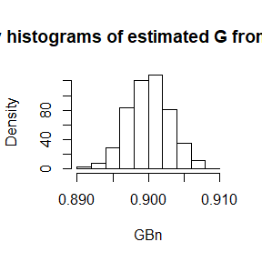

R code:

```r
GiniratioV <- function(X,Xmean=NA){
  #vector X
  if(is.na(Xmean)) Xmean=mean(X)
  sX <- sort(X)
  G=0
  n=length(X)
  for(i in 1:n){
    G=G+(2*i-n-1)*sX[i]
  }
  G=G/n/n/Xmean
  return(G)
}
N=10000
n=1000
set.seed(1234)
# standard lognormal
# random numbers from  standard lognormal and calculate G
# 10000 random numbers and 1000 times

Gln <- replicate(n, expr = {
  X<-rlnorm(N)
  GiniratioV(X)
})
mean(Gln)
```

```
## [1] 0.5205809
```

```r
median(Gln)
```

```
## [1] 0.5207894
```

```r
quantile(Gln,seq(0.1,0.9,0.1))
```

```
##       10%       20%       30%       40%       50%       60%       70%
## 0.5150181 0.5170814 0.5184025 0.5194999 0.5207894 0.5219313 0.5230189
##       80%       90%
## 0.5241111 0.5258198
```

```r
#hist(Gln,freq=F)

# uniform
# random numbers from uniform and calculate G
# 10000 random numbers and 1000 times

Gun <- replicate(n, expr = {
  X<-runif(N)
  GiniratioV(X)
})
mean(Gun)
```

```
## [1] 0.3333285
```

```r
median(Gun)
```

```
## [1] 0.3333709
```

```r
quantile(Gun,seq(0.1,0.9,0.1))
```

```
##       10%       20%       30%       40%       50%       60%       70%
## 0.3301683 0.3312522 0.3321174 0.3327340 0.3333709 0.3340040 0.3346054
##       80%       90%
## 0.3353948 0.3363167
```

```r
#hist(Gun,freq=F)

# Bernoulli(0.1).
# random numbers from  Bernoulli(0.1).  and calculate G
# 10000 random numbers and 1000 times


GBN <- replicate(n, expr = {
  X<-sample(c(0,1),N,replace=T,p=c(0.9,0.1))
  GiniratioV(X)
})
mean(GBn)
```

[output not shown]

```r
median(GBn)
```

```
## [1] 0.9001
```

```r
quantile(GBn,seq(0.1,0.9,0.1))
```

```
##    10%    20%    30%    40%    50%    60%    70%    80%    90%
## 0.8964 0.8976 0.8984 0.8993 0.9001 0.9008 0.9017 0.9026 0.9040
```

```r
#hist(GBn,freq=F)
```

## Q2

6.10 Construct an approximate 95% confidence intervalfor the Gini ratio $?? = E[G]$ if $X$ is lognormal with unknown parameters. Assess the coverage rate of the estimation procedure with a Monte Carlo experiment. ## A2 Based on that if $X$ is Log-normal distribution,$E[G]=erf(\frac{\sigma}{2})$

So I use the 95% confidence interval of variance of $log(X)$ to approximate variance of $E[G]$the 95% con???dence interval of

for the normal distribution ,$(n-1)\frac{s^2}{\sigma^2} \sim \chi^2$ so that the 95% confidence interval of $\sigma^2$ is $[\frac{(n-1)S^2}{\chi^2_{n-1}(1-\alpha\2)} \frac{(n-1)S^2}{\chi^2_{n-1}(\alpha\2)} ]$ $\alpha=0.05$

function varCILN is to return the confidence interval of variance

function GCI is to return the confidence interval of $?? = E[G]$ of data x from log-normal

```r
erfc <- function(s){
  return(2*pnorm(s,0,sqrt(1/2))-1)
}

varCILN <- function(x,a){
  # a level
  # x data from log-normal
  n <- length(x)
  ns_2 <- var(log(x))*n
  return(c(ns_2/qchisq(1-a/2,n-1),ns_2/qchisq(a/2,n-1)))
}

GCI <- function(x,a){
  # a level
  # x data from log-normal
  ci <- varCILN(x,a)
  g1 <- erfc(sqrt(ci[1])/2)
  g2 <- erfc(sqrt(ci[2])/2)
  return(c(g1,g2))
}
```

MC :

I generate 100 random numbers from log-normal(0,1) 10000 times

coverage:

I estimate the ture CI from first simulation

```r
set.seed(100)
N=100
n=10000
X <- rlnorm(N)
gci <- GCI(X,0.05)
gci
```

```
## [1] 0.4758068 0.6005839
```

```r
g <- replicate(n, expr = {
  X <- rlnorm(N)
  erfc(sd(log(X))/2)
})
sum(gci[1]<g & gci[2]>g)/n
```

```
## [1] 0.9077
```

I estimate the CI from ftheory:

`## [1] 0.94`

## Q3

6.B Tests for association based on Pearson product moment correlation $\rho$, Spearman???s rank correlation coefficient $\rho_s$, or Kendall???s coefficient $\tau$ are implemented in cor.test. Show (empirically) that the nonparametric tests based on $\rho_s$ or $\tau$ are less powerful than the correlation test when the sampled distribution is bivariate normal. Find an example of an alternative (a bivariate distribution $(X,Y)$ such that X and Y are dependent) such that at least one of the nonparametric tests have better empirical power than the correlation test against this alternative. ## A3 Show (empirically) that the nonparametric tests based on $\rho_s$ or $\tau$ are less powerful than the correlation test when the sampled distribution is bivariate normal

Find an example of an alternative (a bivariate distribution $(X,Y)$ such that X and Y are dependent) such that at least one of the nonparametric tests have better empirical power than the correlation test against this alternative.

I generate 100 random numbers from bivariate normal ( both means are 0 and variances are 1 , coefficient of association is 0.4),and repeat 10000 times to show how much ratio or the power the p-value of tests are less than 0.05, which means the test shows that true correlation is not equal to 0 and ia “right”

```
## [1] 0.9875
```

nonparametric:

```
## [1] 0.9779
```

nonparametric:

```
## [1] 0.9782
```

It shows that nonparametric tests all have less power than Pearson product moment correlation

P2: $\vec{X}$ is from dirichlet(3,1)

$\vec{Z}$ is from dirichlet(1,3) and id independant with $\vec{X}$

$Y=0.18X+0.5Z$ also is a vector

I generate 100 random numbers 10000 times and test 10000 times

I consider the association between $x_2$ and Y$_1$ ,of course, they are dependant and the true correlation is nearby 0.34

```
## [1] 0.9348
```

nonparametric:

```
## [1] 0.9397
```

nonparametric:

```
## [1] 0.9356
```

It shows that nonparametric tests all have more power than Pearson product moment correlation

R code :

```r
#cor.test(x,y,method="pearson")  Pearson product moment correlation ??,
#cor.test(x,y,method="kendall")  Kendall???s coe???cient ??
#cor.test(x,y,method="spearman") Spearman???s rank correlation coe???cient ??s

cortestall <- function(x,y){
  t1<-cor.test(x,y,method="pearson")
  t2<-cor.test(x,y,method="kendall")
  t3<-cor.test(x,y,method="spearman")
  Assc <- c(t1$p.value,t2$p.value,t3$p.value)
  return(Assc)
}

library(MASS)
set.seed(12)
N=100
n=10000
mu <- c(0,0)
p <- 0.4
Var <- 1
sigma <- matrix(c(1,p,p,1),2,2)
testn <- replicate(n, expr = {
  X <- mvrnorm(N,mu,Var*sigma)
  cortestall(X[,1],X[,2])
})
sum(testn[1,]<=0.05)/n
```

```
## [1] 0.9875
```

```r
sum(testn[2,]<=0.05)/n
```

```
## [1] 0.9779
```

```r
sum(testn[3,]<=0.05)/n
```

```
## [1] 0.9782
```

```r
#install.packages("DirichletReg")
library(DirichletReg)

N=100
n=10000

testn <- replicate(n, expr = {
  X <- rdirichlet(N,c(3,1))
  Z <- rdirichlet(N,c(1,3))
  Y <- 0.18*X + 0.5*Z
  cortestall(X[,2],Y[,1])
})
sum(testn[1,]<=0.05)/n
```

```
## [1] 0.9348
```

```r
sum(testn[2,]<=0.05)/n
```

```
## [1] 0.9397
```

```r
sum(testn[3,]<=0.05)/n
```

```
## [1] 0.9356
```

## H5 A-18033-2018-11-02

## Q1

7.1 Compute a jackknife estimate of the bias and the standard error of the correlation statistic in Example 7.2.

## A1

I compute the jackknife replicates, leave-one-out estimates. The process is same as the book’s. A jackknife estimate of the bias and the standard error of the correlation is shown bellow.

```r
#install.packages("bootstrap")
library(bootstrap)
library(DAAG)
data(law)


#compute the jackknife replicates, leave-one-out estimates
set.seed(4321)
n <- length(law[,1])
theta.jack <- numeric(n)
for (i in 1:n)
theta.jack[i] <- cor(law[-i,])[1,2]
bias <- (n - 1) * (mean(theta.jack) - cor(law)[1,2])
bias
```

```
## [1] -0.006473623
```

```r
mjack <- mean(theta.jack)
se.jack <- sqrt((n-1)/n*sum((theta.jack-mjack)^2))
se.jack
```

```
## [1] 0.1425186
```

```r
c(original=cor(law)[1,2],bias=bias,se=se.jack)
```

```
##     original         bias           se
##  0.776374491 -0.006473623  0.142518619
```

## Q2

Refer to Exercise 7.4. Compute 95% bootstrap confidence intervals for the mean time between failures 1/?? by the standard normal, basic, percentile, and BCa methods. Compare the intervals and explain why they may differ.

The 12 observations are the times in hours between failures of airconditioning equipment [63, Example 1.1]: 3,5,7,18,43,85,91,98,100,130,230,487

## A2

Compare the intervals and explain why they may differ.:

The intervals are shown bellow.

the the bootstrap has its distribution only dependented on the data,and it is random, so that they may be

different . Also, the methods base on different things.

the standard normal: it bases on the asymptotic normal assumption,

basic :it bases on quantile of the difference between an estimator and the parameter

percentile :it seems that bootstrap answer is just like the distrubution of parameter

BCa methods : it bases on the asymptotic normal assumption, but correct some bias

```r
#install.packages("boot")
library(boot)
data(aircondit)
set.seed(4321)
#set up the bootstrap
B <- 2000 #number of replicates
n <- nrow(aircondit) #sample size
a <- 0.05 #level
meantime <- numeric(B) #storage for replicates
#bootstrap estimate of standard error of R

meanairc <- mean(aircondit[,1]) #mean of the original observed sample
for (b in 1:B) {
#randomly select the indices
i <- sample(1:n, size = n, replace = TRUE)
Bairc <- aircondit[i,1]
meantime[b] <- mean(Bairc)
}
mmean <- mean(meantime)  #mean of the bootstrap replicate
SEmeantime <- sqrt(sum((meantime-mmean)^2)/(B-1))

#the standard normal
the_standard_normalCI <- c(meanairc-qnorm(1-a/2)*SEmeantime,meanairc+qnorm(1-a/2)*SEmeantime)
names(the_standard_normalCI) <- c("2.5%","97.5%")

#basic
percentileCI <- quantile(meantime,probs=c(a/2,1-a/2))
basic_CI <- c(2*meanairc-percentileCI[2],2*meanairc-percentileCI[1])

#percentile
#percentileCI

#Bca
x <- aircondit[,1]
alpha <- c(a/2,1-a/2)
zalpha <- qnorm(alpha)
z0 <- qnorm(sum(meantime < mmean) / length(meantime))
mean.jack <- numeric(n)
for (i in 1:n) {
mean.jack[i] <- mean(x[-i])
}
L <- mean(mean.jack) - mean.jack
sa <- sum(L^3)/(6 * sum(L^2)^1.5)
adj.alpha <- pnorm(z0 + (z0+zalpha)/(1-sa*(z0+zalpha)))
BCa_CI <- quantile(meantime, adj.alpha, type=6)


#the standard normal
the_standard_normalCI
```

```
##      2.5%     97.5%
##  35.25234 180.91433
```

```r
#the standard normal
basic_CI
```

```
##     97.5%      2.5%
##  30.73333 169.00208
```

```r
#percentile
percentileCI
```

```
##      2.5%     97.5%
##  47.16458 185.43333
```

```r
#Bca
BCa_CI
```

```
## 7.258344% 99.64576%
##  58.58333 235.05621
```

```r
#another
x=aircondit$hours
meanx<-function(x,i) mean(x[i])
de <- boot(data=x,statistic=meanx, R =B)
ci <- boot.ci(de,type=c("norm","basic","perc","bca"))
ci
```

```
## BOOTSTRAP CONFIDENCE INTERVAL CALCULATIONS
## Based on 2000 bootstrap replicates
##
## CALL :
## boot.ci(boot.out = de, type = c("norm", "basic", "perc", "bca"))
##
## Intervals :
## Level      Normal              Basic
## 95%   ( 35.1, 183.7 )   ( 24.8, 168.9 )
##
## Level     Percentile            BCa
## 95%   ( 47.3, 191.4 )   ( 56.5, 227.7 )
## Calculations and Intervals on Original Scale
## Some BCa intervals may be unstable
```

## Q3

Refer to Exercise 7.7. Obtain the jackknife estimates of bias and standard error of $\hat\theta$.

## A3

Same as the Q1

I compute the jackknife replicates, leave-one-out estimates.

```r
attach(scor)
datascores  <-scor
n <- length(datascores[,1])
theta.jack <- numeric(n)
calthta <- function(X){
#X show be a matrix n*n
eig <- eigen(X)
sort_eig <- sort(eig$values,decreasing=T)
return(sort_eig[1]/sum(sort_eig))
}

for (i in 1:n) theta.jack[i] <- calthta(cov(datascores[-i,]))
bias <- (n - 1) * (mean(theta.jack) - calthta(cov(datascores)))
bias
```

```
## [1] 0.001069139
```

```r
mjack <- mean(theta.jack)
sc.jack <- sqrt((n-1)/n*sum((theta.jack-mjack)^2))
sc.jack
```

```
## [1] 0.04955231
```

## Q4

7.11 In Example 7.18, leave-one-out (n-fold) cross validation was used to select the best fitting model. Use leave-two-out cross validation to compare the models.

## A4

Also Chosse moderl 2

The fitted regression equation for Model 2 is $\hat Y = 24 .49262???1.39334X +0 .05452X^2$

```r
#install.packages("DAAG")
#install.packages("caTools")
library(DAAG)
library(caTools)
attach(ironslag)
n <- length(magnetic) #in DAAG ironslag
K=2 # knife number
kjack <- combs(1:n,K) #create the all combinations of 2 elements from 1:n
N <- choose(n,K) #number of K
e1 <- e2 <- e3 <- e4 <- matrix(,N,K)

# for n-fold cross validation
# fit models on leave-two-out samples


for (i in 1:N) {
k <- kjack[i,]
y <- magnetic[-k]
x <- chemical[-k]
J1 <- lm(y ~ x)
yhat1 <- J1$coef[1] + J1$coef[2] * chemical[k]
e1[i,] <- magnetic[k] - yhat1
J2 <- lm(y ~ x + I(x^2))
yhat2 <- J2$coef[1] + J2$coef[2] * chemical[k] + J2$coef[3] * chemical[k]^2
e2[i,] <- magnetic[k] - yhat2
J3 <- lm(log(y) ~ x)
logyhat3 <- J3$coef[1] + J3$coef[2] * chemical[k]
yhat3 <- exp(logyhat3)
e3[i,] <- magnetic[k] - yhat3
J4 <- lm(log(y) ~ log(x))
logyhat4 <- J4$coef[1] + J4$coef[2] * log(chemical[k])
yhat4 <- exp(logyhat4)
e4[i,] <- magnetic[k] - yhat4
}

c(sum(e1^2),sum(e2^2),sum(e3^2),sum(e4^2))/N/K
```

```
## [1] 19.57227 17.87018 18.45491 20.46718
```

## H6 A-18033-2018-11-16

## Q1

8.1 Implement the two-sample Cramer-von Mises test for equal distributions as a permutation test. Apply the test to the data in Examples 8.1 and 8.2.

## A1

Here the sample evidence supports the alternative hypothesis that the distributions di???er.

```r
#install.packages("RANN")
#install.packages("energy")
#install.packages("devtools")
#install.packages("Ball")
library(RANN)
library(boot)
library(energy)
library(Ball)
library(devtools)
#8.1
attach(chickwts)
set.seed(1234)
x <- sort(as.vector(weight[feed == "soybean"]))
y <- sort(as.vector(weight[feed == "linseed"]))
cvMTS <- function(X,Y){
#Cram??r???von Mises Two Sample  statistic
#X  Y : vector
XYrank <- rank(c(X,Y))
N <- length(X)
M <- length(Y)
U= N*sum((XYrank[1:N]-1:N)^2)+M*sum((XYrank[(N+1):(N+M)]-1:M)^2)
T=U/M/N/(N+M)-(4*M*N-1)/6/(M+N)
return(T)
}
## start the replicate
R <- 999 #number of replicates
z <- c(x, y) #pooled sample
K <- 1:length(z)
T <- numeric(R) #storage for replicates options(warn = -1)
T0 <- cvMTS(x,y)
for (i in 1:R) {
#generate indices k for the first sample
k <- sample(K, size = 14, replace = FALSE)
x1 <- z[k]
y1 <- z[-k]
T[i] <- cvMTS(x1,y1)
}
P0 <- mean(c(T0, T) >= T0)
pvalue <- min(2*P0,2*(1-P0))
pvalue
```

```
## [1] 0
```

```r
#pvalue < 0.05
#Thus, none of the replicates are as large as the observed test statistic.
#Here the sample evidence supports the alternative hypothesis that the distributions di???er.
detach(chickwts)
```

## Q2

Design experiments for evaluating the performance of the NN, energy, and ball methods in various situations. I Unequal variances and equal expectations I Unequal variances and unequal expectations I Non-normal distributions: t distribution with 1 df (heavy-tailed distribution), bimodel distribution (mixture of two normal distributions) I Unbalanced samples (say, 1 case versus 10 controls) I Note: The parameters should be choosen such that the powers are distinguishable (say, range from 0.3 to 0.9).

## A2

```r
#PLUS

#NN
Tn <- function(z, ix, sizes,k) {
n1 <- sizes[1]
n2 <- sizes[2]
n <- n1 + n2
if(is.vector(z))  z <- data.frame(z,0)
z <- z[ix, ]
NN <- nn2(data=z, k=k+1)
block1 <- NN$nn.idx[1:n1,-1]
block2 <- NN$nn.idx[(n1+1):n,-1]
i1 <- sum(block1 < n1 + .5)
i2 <- sum(block2 > n1+.5)
return((i1 + i2) / (k * n) )
}

NNtest_1 <- function(x,y,NumR=999,k=3){
N <- c(length(x), length(y))
z <- c(x,y)
boot.obj <- boot(data = z, statistic = Tn, R = NumR, sim = "permutation", sizes = N,k=k)
ts <- c(boot.obj$t0,boot.obj$t)
p.value <- mean(ts>=ts[1])
return(p.value)
}

#Energy test
Energy_test <- function(x,y,NumR=999){
N <- c(length(x), length(y))
z <- c(x,y)
boot.obs <- eqdist.etest(z, sizes=N, R=NumR)
p.value <- boot.obs$p.value
return(p.value)
}


#install_github("Mamba413/Ball", build_vignettes = TRUE)

#
alpha <- 0.05;

##1
##Unequal variances and equal expectations
set.seed(123)
m <- 1000; #number od tests
k<-3;
p<-2;
mu <- 0;
n1 <- n2 <- 20;
R<-999;
sigma1 <- 1
sigma2 <- 2.5
#x N(0,1) 20 y N(0,4) 20
p.values1 <- matrix(NA,m,3)
for(i in 1:m){
x <- rnorm(n1,mu,sigma1)
y <- rnorm(n2,mu,sigma2)
z <- c(x,y)
p.values1[i,1] <- NNtest_1(x,y,R,k)
p.values1[i,2] <- Energy_test(x,y,R)
p.values1[i,3] <- bd.test(x,y,R=R,seed=i*123)$p.value
}
pow1 <- colMeans(p.values1<alpha)
pow1
```

```
## [1] 0.482 0.504 0.777
```

```r
##2
##Unequal variances and unequal expectations
set.seed(123)
m <- 1000; #number od tests
k<-3;
p<-2;
mu1 <- 0;
mu2 <- 1
n1 <- n2 <- 20;
R<-999;
sigma1 <-1
sigma2 <-2
R<-100;
#x N(0,1) 20  y N(1,4) 20
p.values2 <- matrix(NA,m,3)
for(i in 1:m){
x <- rnorm(n1,mu1,sigma1)
y <- rnorm(n2,mu2,sigma2)
z <- c(x,y)
p.values2[i,1] <- NNtest_1(x,y,R,k)
p.values2[i,2] <- Energy_test(x,y,R)
p.values2[i,3] <- bd.test(x,y,R=R,seed=i*123)$p.value
}
pow2 <- colMeans(p.values2<alpha)
pow2
```

```
## [1] 0.433 0.679 0.711
```

```r
##3.1
##Non-normal distributions: t distribution with 1 df (heavy-tailed distribution),bimodel distribution (mixture of two normal distributions)
set.seed(123)
m <- 1000; #number od tests
k<-3;
n1 <- n2 <- 20;
df=1
R<-999;
p=0.4
mu1 =-1
mu2 = 1
sigma1 =1
sigma2=1
#x t1 30  y 0.3N(-1,1)+0.7N(1,2) 30
p.values3 <- matrix(NA,m,3)
for(i in 1:m){
x <- rt(n1,df=df)
y <- 0.3 * rnorm(n2,mu1,sigma1) + 0.7*rnorm(n2,mu2,sigma2)
z <- c(x,y)
p.values3[i,1] <- NNtest_1(x,y,R,k)
p.values3[i,2] <- Energy_test(x,y,R)
p.values3[i,3] <- bd.test(x,y,R=999,seed=i*123)$p.value
}
pow3 <- colMeans(p.values3<alpha)
pow3
```

```
## [1] 0.344 0.606 0.688
```

```r
#4
#Unbalanced samples (say, 1 case versus 10 controls)
set.seed(123)
m <- 1000; #number od tests
k<-3;
n1 <- 100;
n2 <- 100/10
R<-999;
mu1 =-1
mu2 = 0
sigma1 =1
sigma2=2
#x N(-1,1) 100  y N(1,2) 10
p.values4 <- matrix(NA,m,3)
for(i in 1:m){
x <- rnorm(n1,mu1,sigma1)
y <- rnorm(n2,mu2,sigma2)
z <- c(x,y)
p.values4[i,1] <- NNtest_1(x,y,R,k)
p.values4[i,2] <- Energy_test(x,y,R)
p.values4[i,3] <- bd.test(x,y,R=999,seed=i*123)$p.value
}
pow4 <- colMeans(p.values4<alpha)
pow4
```

```
## [1] 0.577 0.797 0.572
```

## Q3

9.3 Use the Metropolis-Hastings sampler to generate random variables from a standard Cauchy distribution. Discard the ???rst 1000 of the chain, and compare the deciles of the generated observations with the deciles of the standard Cauchydistribution(seeqcauchyorqtwithdf=1). RecallthataCauchy(??,??) distribution has density function

$f(x)=\frac{1}{\theta??(1+[(x???\eta)/\theta]^2}$, $-\infty<x<\infty$ $\theta>0$.

The standard Cauchy has the Cauchy(?? =1,??= 0) density. (Note that the standard Cauchy density is equal to the Student t density with one degree of freedom.)

## A3

it is unavoidable that there is differ between MCMC estimations and theoretical value ,beacese of only 5000 samplers

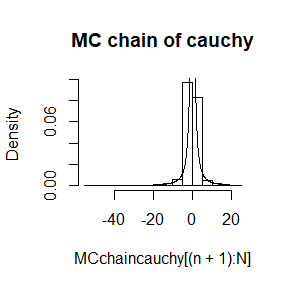

```r
#9.3
#the proposal distributio:normal
theta=1
eta=0
MCMC <- function(N,theta,eta,ssigma=1,xstart=0,LM){
#  k=0
mchain <- numeric(N)
mchain[1] <- xstart
for(i in 1:(N-1)){
r <-rnorm(1,mchain[i],ssigma)
a = LM(r,theta,eta) * dnorm(mchain[i],mean=r,sd=ssigma) / LM(mchain[i],theta,eta) / dnorm(r,mean=mchain[i],sd=ssigma)
nr <-runif(1)
#    if(nr<a) k=k+1
if(nr<a) mchain[i+1]=r else mchain[i+1]=mchain[i]
}
#  return(c(k,mchain))
return(mchain)
}
set.seed(123)
sigma = 8
#sigma of the proposal distributio
N=5000
n=1000

LMcauchy <- function(x,theta,eta){
return(1/theta/pi/(1+((x-eta)/theta)^2))
}
theta=1
eta=0

MCchaincauchy <- MCMC(N,1,0,sigma,0,LMcauchy)
#accrptation rate : 30%
#MCchaincauchy[1]
hist(MCchaincauchy[(n+1):N],freq = FALSE,main="MC chain of cauchy")
x <- seq(min(MCchaincauchy[(n+1):N]),max(MCchaincauchy[(n+1):N]),length=1000)
lines(x,LMcauchy(x,1,0))
```

```r
xx <- seq(0.1,0.9,0.1)
MC_deciles <- quantile(MCchaincauchy[(n+1):N],xx)
Th_deciles <- qcauchy(xx)
ans <- rbind(MC_deciles,Th_deciles,abs(Th_deciles-MC_deciles))
rownames(ans)[3] <- "differ"
ans
```

```
##                   10%         20%         30%         40%        50%
## MC_deciles -2.9353678 -1.45464343 -0.80573171 -0.38707703 -0.1135152
## Th_deciles -3.0776835 -1.37638192 -0.72654253 -0.32491970  0.0000000
## differ      0.1423157  0.07826151  0.07918919  0.06215733  0.1135152
##                  60%       70%       80%       90%
## MC_deciles 0.1961879 0.5953806 1.1740178 2.6918223
## Th_deciles 0.3249197 0.7265425 1.3763819 3.0776835
## differ     0.1287318 0.1311620 0.2023641 0.3858612
```

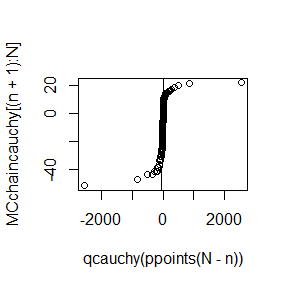

```r
qqplot(qcauchy(ppoints(N-n)),MCchaincauchy[(n+1):N])
qqline(MCchaincauchy[(n+1):N],distribution = qcauchy)
```

## Q4

9.6 Rao [220, Sec. 5g] presented an example on genetic linkage of 197 animals in four categories (also discussed in [67, 106, 171, 266]). The group sizes are (125,18,20,34). Assume that the probabilities of the corresponding multinomial distribution are

$(\frac1 2 + \frac?? 4, \frac{1-??} 4 , \frac{1-??} 4 , \frac?? 4)$.

Estimate the posterior distribution of ?? given the observed sample, using one of the methods in this chapter.

## A4

MCMC estimates:

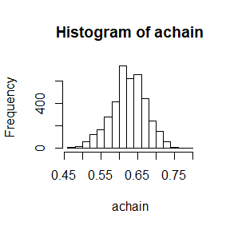

```r
#9.6
#It is obvious that theta belongs to [0,1]
#i chooose the uniform as the prior distrubution
#
#(125,18,20,34)
#

set.seed(214)
CMD <- function(theta){
#return the probabilities vector of the corresponding multinomial distribution
if(theta >1) return(c(0,0,0,0))
if(theta <0) return(c(0,0,0,0))
return(c(0.5+theta/4,(1-theta)/4,(1-theta)/4,theta/4))
}

LMCMD <- function(r,data){
p <- CMD(r)
return(p[1]^data[1]*p[2]^data[2]*p[3]^data[3]*p[4]^data[4])
}

MCMC2 <- function(N,data,startx=0.5){
mchain <- numeric(N)
mchain[1] = startx
#k=0
for(i in 1:(N-1)){
r <- runif(1)
a = LMCMD(r,data)  / LMCMD(mchain[i],data)
nr <-runif(1)
if(nr<a) mchain[i+1]=r else mchain[i+1]=mchain[i]
}
return(mchain)
}

data <- c(125,18,20,34)
mchain2 <- MCMC2(N,data,0.5)
# PS: acceptation rate is 16%
achain <- mchain2[1001:N]
hist(achain)
```

```r
mean(achain)
```

```
## [1] 0.6248848
```

## H8 A-18033-2018-11-30

## Q1

11.6 Write a function to compute the cdf of the Cauchy distribution, which has density
$$\frac{1}{\theta\pi(1+[(x-\eta)/\theta]^2),-\infty<x<\infty}$$
, where $\theta>0$. Compare your results to the results from the R function pcauchy. (Also see the source code in pcauchy.c.)

## A1

```r
LMF <-function(y,theta,eta){
  #theta : scale parameter
  #eta : the location parameter
  1/(theta*3.141592653*(1+((y-eta)/theta)^2))
}
# the cauchy pdf

pdf <-function(x,theta,eta,lower.tail=TRUE){
  if(lower.tail) result<-integrate(LMF,lower = -Inf,upper = x,rel.tol=.Machine$double.eps^0.25,theta=theta,eta=eta)
  else result<-integrate(LMF,lower = x,upper = Inf,rel.tol=.Machine$double.eps^0.25,theta=theta,eta=eta)
  return(result$value)
}
pdf(2,2,1,lower.tail = F )
```

```
## [1] 0.3524164
```

```r
pcauchy(2,location = 1,scale = 2,lower.tail = F)
```

```
## [1] 0.3524164
```

The result is same

## Q2 Exercises 3

- A-B-O blood type problem
- Let the three alleles be A, B, and O.

Comparation of them

| Genotype | AA | BB | OO | AO | BO | AB | Sum |
| --- | --- | --- | --- | --- | --- | --- | --- |
| Frequency | p2 | q2 | r2 | 2pr | 2qr | 2pq | 1 |
| Count | nAA | nBB | nOO | nAO | nBO | nAB | n |

- Observed data: $n_{A\cdot}=n_{AA}+n_{AO}=28$ (A-type), $n_{B\cdot}=n_{BB}+n_{BO}=24$ (B-type), $n_{OO}=41$ (O-type), $n_{AB}=70$ (AB-type).
- Use EM algorithm to solve MLE of $p$ and $q$ (consider missing data $n_{AA}$ and $n_{BB}$).
- Record the maximum likelihood values in M-steps, are they increasing?

## A2

```r
#install.packages("nloptr")
library(nloptr)
# mle
logL <- function(x,xpart,n.A,n.B,nOO,nAB) {
  #x[1] p
  #x[2] q
  #xpart[1] p0
  #xpart[2] q0
  r1<-1-sum(xpart)
  nAA<-n.A*xpart[1]^2/(xpart[1]^2+2*xpart[1]*r1)
  nBB<-n.B*xpart[2]^2/(xpart[2]^2+2*xpart[2]*r1)
  r<-1-sum(x)
  return(-2*nAA*log(x[1])-2*nBB*log(x[2])-2*nOO*log(r)-
           (n.A-nAA)*log(2*x[1]*r)-(n.B-nBB)*log(2*x[2]*r)-nAB*log(2*x[1]*x[2]))
}

# constraint function
limitx <- function(x,xpart,n.A,n.B,nOO,nAB) {
  return(sum(x)-0.999999)
}

opts <- list("algorithm"="NLOPT_LN_COBYLA",
             "xtol_rel"=1.0e-8)
EMmle<-NULL
r<-matrix(0,1,2)
r<-rbind(r,c(0.2,0.2))
# first p0 and q0
j<-2
while (sum((r[j,]-r[j-1,])^2)>1e-10) {
  res <- nloptr( x0=c(0.2,0.2),
                 eval_f=logL,
                 lb = c(0,0), ub = c(1,1),
                 eval_g_ineq =limitx,
                 opts = opts, xpart=r[j,],n.A=28,n.B=24,nOO=41,nAB=70 )
  j<-j+1
  r<-rbind(r,res$solution)
  EMmle<-c(EMmle,logL(x=r[j,],xpart=r[j-1,],n.A=28,n.B=24,nOO=41,nAB=70))
}
#Answer:
r[nrow(r),1:2]
```

```
## [1] 0.3273433 0.3104259
```

```r
#EM:
r
```

```
##           [,1]      [,2]
## [1,] 0.0000000 0.0000000
## [2,] 0.2000000 0.2000000
## [3,] 0.3128834 0.2988606
## [4,] 0.3252817 0.3088035
## [5,] 0.3270424 0.3101899
## [6,] 0.3272999 0.3103919
## [7,] 0.3273377 0.3104216
## [8,] 0.3273433 0.3104259
```

```r
# negetive log likelihood
EMmle
```

```
## [1] 276.5216 282.9444 283.7928 283.9155 283.9335 283.9362
```

## H9 A-18033-2018-12-07

## Q1 Exercises 3 P204

Use both for loops and lapply() to fit linear models to the mtcars using the formulas stored in this list: formulas <- list( mpg ~ disp, mpg ~ I(1 / disp), mpg ~ disp + wt, mpg ~ I(1 / disp) + wt ) # Answer I use lmloop to save the answer of loops

```r
attach(mtcars)
formulas <- list( mpg ~ disp,
    mpg ~ I(1 / disp),
    mpg ~ disp + wt,
    mpg ~ I(1 / disp) + wt
)
#Loops
lmloop <- list()
for (k in 1:length(formulas)) {
  lmloop[[k]] <- lm(formulas[[k]])
}
lmloop
```

```
## [[1]]
##
## Call:
## lm(formula = formulas[[k]])
##
## Coefficients:
## (Intercept)         disp
##    29.59985     -0.04122
##
##
## [[2]]
##
## Call:
## lm(formula = formulas[[k]])
##
## Coefficients:
## (Intercept)    I(1/disp)
##       10.75      1557.67
##
##
## [[3]]
##
## Call:
## lm(formula = formulas[[k]])
##
## Coefficients:
## (Intercept)         disp           wt
##    34.96055     -0.01772     -3.35083
##
##
## [[4]]
##
## Call:
## lm(formula = formulas[[k]])
##
## Coefficients:
## (Intercept)    I(1/disp)           wt
##      19.024     1142.560       -1.798
```

```r
#Lapply
lapply(formulas,lm)
```

```
## [[1]]
##
## Call:
## FUN(formula = X[[i]])
##
## Coefficients:
## (Intercept)         disp
##    29.59985     -0.04122
##
##
## [[2]]
##
## Call:
## FUN(formula = X[[i]])
##
## Coefficients:
## (Intercept)    I(1/disp)
##       10.75      1557.67
##
##
## [[3]]
##
## Call:
## FUN(formula = X[[i]])
##
## Coefficients:
## (Intercept)         disp           wt
##    34.96055     -0.01772     -3.35083
##
##
## [[4]]
##
## Call:
## FUN(formula = X[[i]])
##
## Coefficients:
## (Intercept)    I(1/disp)           wt
##      19.024     1142.560       -1.798
```

```r
#same answers
```

## Q2 Exercises 4 P204

Fit the model mpg ~ disp to each of the bootstrap replicates of mtcars in the list below by using a for loop and lapply(). Can you do it without an anonymous function? bootstraps <- lapply(1:10, function(i) { rows <- sample(1:nrow(mtcars), rep = TRUE) mtcars[rows, ] })

## A2

```r
set.seed(123)
#follow the question:
bootstraps <- lapply(1:10, function(i) {
  rows <- sample(1:nrow(mtcars), rep = TRUE)
  mtcars[rows, ] })

#Loops
lmboots<-list()
for(i in 1:length(bootstraps)){
  lmboots[[i]] <- lm(mpg~disp,data =bootstraps[[i]])
}
lmboots
```

```
## [[1]]
##
## Call:
## lm(formula = mpg ~ disp, data = bootstraps[[i]])
##
## Coefficients:
## (Intercept)         disp
##     30.0287      -0.0434
##
##
## [[2]]
##
## Call:
## lm(formula = mpg ~ disp, data = bootstraps[[i]])
##
## Coefficients:
## (Intercept)         disp
##    29.44060     -0.03799
##
##
## [[3]]
##
## Call:
## lm(formula = mpg ~ disp, data = bootstraps[[i]])
##
## Coefficients:
## (Intercept)         disp
##    28.92155     -0.03918
##
##
## [[4]]
##
## Call:
## lm(formula = mpg ~ disp, data = bootstraps[[i]])
##
## Coefficients:
## (Intercept)         disp
##    29.10046     -0.04044
##
##
```

[output cut: 43 more lines]

```
## lm(formula = mpg ~ disp, data = bootstraps[[i]])
##
## Coefficients:
## (Intercept)         disp
##    27.47647     -0.03299
##
##
## [[10]]
##
## Call:
## lm(formula = mpg ~ disp, data = bootstraps[[i]])
##
## Coefficients:
## (Intercept)         disp
##    28.61819     -0.03719
```

```r
#Lapply
set.seed(123)
lapply(bootstraps,lm,formula=mpg~disp)
```

```
## [[1]]
##
## Call:
## FUN(formula = ..1, data = X[[i]])
##
## Coefficients:
## (Intercept)         disp
##     30.0287      -0.0434
##
##
## [[2]]
##
## Call:
## FUN(formula = ..1, data = X[[i]])
##
## Coefficients:
## (Intercept)         disp
##    29.44060     -0.03799
##
##
## [[3]]
##
## Call:
## FUN(formula = ..1, data = X[[i]])
##
## Coefficients:
## (Intercept)         disp
##    28.92155     -0.03918
##
##
## [[4]]
##
## Call:
## FUN(formula = ..1, data = X[[i]])
##
## Coefficients:
## (Intercept)         disp
##    29.10046     -0.04044
##
##
```

[output cut: 43 more lines]

```
## FUN(formula = ..1, data = X[[i]])
##
## Coefficients:
## (Intercept)         disp
##    27.47647     -0.03299
##
##
## [[10]]
##
## Call:
## FUN(formula = ..1, data = X[[i]])
##
## Coefficients:
## (Intercept)         disp
##    28.61819     -0.03719
```

```r
#same seed ,same answer
```

## Q3 Exercises 5 P204

For each model in the previous two exercises,extract $R^2$ using the function below. rsq <- function(mod) summary(mod)$r.squared

## A3

```r
#From the question:
rsq <- function(mod) summary.lm(mod)$r.squared
#Q1 Exercises 3
#Loops
rsqloopsQ3 <- NULL
for (i in seq_along(formulas)) {
 rsqloopsQ3[i] <- rsq(lm(formulas[[i]]))
}
rsqloopsQ3
```

```
## [1] 0.7183433 0.8596865 0.7809306 0.8838038
```

```r
#lapply
lapply(lapply(formulas,lm),rsq)
```

```
## [[1]]
## [1] 0.7183433
##
## [[2]]
## [1] 0.8596865
##
## [[3]]
## [1] 0.7809306
##
## [[4]]
## [1] 0.8838038
```

```r
#Q2 Exercises 4
#Loops
rsqloopsQ4 <- NULL
set.seed(123)
for(i in seq_along(bootstraps)){
 rsqloopsQ4[i] <- rsq(lm(mpg~disp,data =bootstraps[[i]]))
}
rsqloopsQ4
```

```
##  [1] 0.7475099 0.7179526 0.7571433 0.6921848 0.8488426 0.7702828 0.7491175
##  [8] 0.7843995 0.6779810 0.7887093
```

```r
#lapply
set.seed(123)
lapply(lapply(bootstraps,lm,formula=mpg~disp),rsq)
```

```
## [[1]]
## [1] 0.7475099
##
## [[2]]
## [1] 0.7179526
##
## [[3]]
## [1] 0.7571433
##
## [[4]]
## [1] 0.6921848
##
## [[5]]
## [1] 0.8488426
##
## [[6]]
## [1] 0.7702828
##
## [[7]]
## [1] 0.7491175
##
## [[8]]
## [1] 0.7843995
##
## [[9]]
## [1] 0.677981
##
## [[10]]
## [1] 0.7887093
```

## Q4 Exercises 3 P213

The following code simulates the performance of a t-test for non-normal data. Use sapply() and an anonymous function to extract the p-value from every trial. trials <- replicate( 100, t.test(rpois(10, 10), rpois(7, 10)), simplify = FALSE ) Extra challenge: get rid of the anonymous function by using [[ directly.

## A4

```r
#sapply
trials <- replicate( 100, t.test(rpois(10, 10), rpois(7, 10)), simplify = FALSE )
p_value<-function(mod) mod$p.value
sapply(trials, p_value)
```

```
##   [1] 9.813226e-01 1.619096e-05 6.242135e-01 6.693526e-01 5.677105e-01
##   [6] 6.610740e-01 5.951636e-01 5.005347e-01 4.763110e-01 3.429965e-01
##  [11] 8.155394e-01 7.197238e-01 1.244336e-01 2.229164e-01 1.113099e-02
##  [16] 4.625765e-01 6.515865e-01 1.658793e-01 9.342672e-01 8.011934e-01
##  [21] 4.627657e-01 5.927934e-01 2.929669e-01 5.737967e-01 3.451537e-02
##  [26] 2.739138e-01 2.656151e-01 8.196695e-01 6.647355e-01 8.056529e-01
##  [31] 5.060850e-01 7.106543e-01 2.321066e-01 1.106223e-01 5.459279e-01
##  [36] 1.865470e-02 2.433776e-01 2.688851e-01 9.819256e-01 4.940184e-01
##  [41] 3.268275e-01 8.000439e-01 9.822499e-01 1.936454e-01 7.390101e-01
##  [46] 3.888930e-02 4.350424e-01 7.434339e-02 5.787441e-01 4.864951e-01
##  [51] 1.476288e-01 5.524909e-01 7.129280e-01 8.683479e-03 9.053256e-02
##  [56] 4.415463e-01 4.955063e-01 1.745328e-01 6.615399e-01 4.479199e-01
##  [61] 2.885849e-01 3.028567e-02 1.018907e-01 1.811861e-02 6.376441e-01
##  [66] 1.408742e-02 9.008128e-02 4.515933e-01 8.703291e-01 7.250768e-01
##  [71] 8.183571e-01 8.465036e-01 8.786838e-01 1.651543e-01 3.951569e-01
##  [76] 1.754280e-01 3.649865e-01 7.224226e-02 6.565152e-01 9.946559e-01
##  [81] 3.715952e-01 8.424336e-02 4.549887e-01 8.530113e-01 1.970777e-01
##  [86] 2.298117e-01 1.148832e-01 7.769502e-01 4.934348e-01 3.526049e-01
##  [91] 2.036013e-01 8.838914e-01 6.474880e-02 4.089082e-01 5.780132e-01
##  [96] 8.011408e-01 5.956061e-01 9.266689e-01 9.923205e-02 1.763972e-01
```

```r
#[[ directly
#??
```

## Q5 Exercises 6 in page 214

Implement a combination of Map() and vapply() to create an lapply() variant that iterates in parallel over all of its inputs and stores its outputs in a vector (or a matrix). What arguments should the function take?

## A5

```r
Mapvapplay<-function (f,n,type, ...) {
  #n:the length of output
  f <- match.fun(f)
  fM=Map(f, ...)
  if(type=="numeric")  return(vapply(fM,cbind,numeric(n)))
  else if (type=="character") return(vapply(fM,cbind,character(n)))
  else if (type=="complex") return(vapply(fM,cbind,complex(n)))
  else if (type=="logical") return(vapply(fM,cbind,logical(n)))
}

#examples :Q3
rsq <- function(mod) summary.lm(mod)$r.squared
Mapvapplay(rsq,1,"numeric",lapply(formulas,lm))
```

```
## [1] 0.7183433 0.8596865 0.7809306 0.8838038
```

```r
#example 2
comparexy <- function(x,y) return(x<y)
x<- list(1:10,2:11,3:12)
y<- list(10:1,11:2,12:3)
Mapvapplay(comparexy,10,"logical",x,y)
```

```
##        [,1]  [,2]  [,3]
##  [1,]  TRUE  TRUE  TRUE
##  [2,]  TRUE  TRUE  TRUE
##  [3,]  TRUE  TRUE  TRUE
##  [4,]  TRUE  TRUE  TRUE
##  [5,]  TRUE  TRUE  TRUE
##  [6,] FALSE FALSE FALSE
##  [7,] FALSE FALSE FALSE
##  [8,] FALSE FALSE FALSE
##  [9,] FALSE FALSE FALSE
## [10,] FALSE FALSE FALSE
```

## H10 A-18033-12-14

## Q1 exercise 4

Make a faster version of chisq.test() that only computes the chi-square test statistic when the input is two numeric vectors with no missing values. You can try simplifying chisq.test() or by coding from the mathematical definition (http://en. wikipedia.org/wiki/Pearson%27s_chi-squared_test).

## A1

```r
library(microbenchmark)
fastchisq.test<-function(x,y){
  #Pearson's Chi-squared test
  #input two numeric vectors x,y
  #x,y should have same length
  #computes the chi-square test statistic
  X <- rbind(x,y)
  n<-sum(c(x,y))
  rs <-rowSums(X)
  cs <-colSums(X)
  np <-rs %*% t(cs)/n
  return(sum((X-np)^2/np))
}
x<-c(42,13,24)
y<-c(111,50,50)
fastchisq.test(x,y)
```

```
## [1] 2.396744
```

```r
chisq.test(rbind(x,y))
```

```
##
##  Pearson's Chi-squared test
##
## data:  rbind(x, y)
## X-squared = 2.3967, df = 2, p-value = 0.3017
```

```r
microbenchmark(t1=fastchisq.test(x,y),t2=chisq.test(rbind(x,y)))
```

```
## Unit: microseconds
##  expr     min      lq     mean  median      uq       max neval
##    t1  26.257  28.080 161.7659  32.821  33.733 13085.551   100
##    t2 137.482 139.123 143.5687 140.217 142.223   261.836   100
```

```r
#it is obivous that fastchisq.test is faster
```

## Q2 exercise 5

Can you make a faster version of table() for the case of an input of two integer vectors with no missing values? Can you use it to speed up your chi-square test?

## A2

```r
fasttable<-function(...,dnn = list.names(...),deparse.level = 1){
  #input: of two integer vectors
  #two integer vectors should have same length
  #output:
  #sort by quickSort
  list.names <- function(...) {
    l <- as.list(substitute(list(...)))[-1L]
    nm <- names(l)
    fixup <- if (is.null(nm))
    seq_along(l)
    else nm == ""
    dep <- vapply(l[fixup], function(x) switch(deparse.level +
          1, "", if (is.symbol(x)) as.character(x) else "",
            deparse(x, nlines = 1)[1L]), "")
    if (is.null(nm))
      dep
    else {
      nm[fixup] <- dep
      nm
    }
  }
  args <- list(...)
  if (!length(args))
    stop("nothing to tabulate")
  if (length(args) == 1L && is.list(args[[1L]])) {
    args <- args[[1L]]
    if (length(dnn) != length(args))
    dnn <- if (!is.null(argn <- names(args)))
    argn
    else paste(dnn[1L], seq_along(args), sep = ".")
  }
  bin <- 0L
  lens <- NULL
  dims <- integer()
  pd <- 1L
  dn <- NULL
  for (a in args) {
    if (is.null(lens))   lens <- length(a)
    else if (length(a) != lens)
    stop("all arguments must have the same length")
    fact.a <- is.factor(a)
    if (!fact.a) {
      a0 <- a
      a <- factor(a)
    }
    ll <- levels(a)
    a <- as.integer(a)
    nl <- length(ll)
    dims <- c(dims, nl)
    dn <- c(dn, list(ll))
    bin <- bin + pd * (a - 1L)
    pd <- pd * nl
 }
  names(dn) <- dnn
  bin <- bin[!is.na(bin)]
  if (length(bin)) bin <- bin + 1L
  y <- array(tabulate(bin, pd), dims, dimnames = dn)
  class(y) <- "table"
  y
}
# I delete all useless judgement statement

x <- c(rep(1,100),rep(2,100),rep(3,100),rep(4,100),rep(5,100))
y <- c(rep(1:5,100))
fasttable(x,y)
```

```
##    y
## x    1  2  3  4  5
##   1 20 20 20 20 20
##   2 20 20 20 20 20
##   3 20 20 20 20 20
##   4 20 20 20 20 20
##   5 20 20 20 20 20
```

```r
table(x,y)
```

```
##    y
## x    1  2  3  4  5
##   1 20 20 20 20 20
##   2 20 20 20 20 20
##   3 20 20 20 20 20
##   4 20 20 20 20 20
##   5 20 20 20 20 20
```

```r
microbenchmark(t1=fasttable(x,y),t2=table(x,y))
```

```
## Unit: microseconds
##  expr     min      lq     mean  median       uq     max neval
##    t1 473.711 478.816 492.9798 488.298 495.7730 635.625   100
##    t2 486.839 491.944 509.0036 501.061 510.7245 685.950   100
```